# 統計学2

課題3の解答例

矢内 勇生

2019-05-15

# 準備

必要なパッケージを読み込む。

```r
library("tidyverse")
library("ggbeeswarm")
```

**Macユーザのみ**次のコードも実行する。

```r
theme_set(theme_gray(base_size = 10, base_family = "HiraginoSans-W3"))
```

**データがダウンロード済でない場合のみ**、次のコードチャンクを実行する。

```r
dir.create("data")
download.file(url = "http://yukiyanai.github.io/jp/classes/stat2/contents/data/fake-score.csv",
              destfile = "data/fake-score.csv")
```

データを読み込む。

```r
myd <- read_csv("data/fake-score.csv")
```

データを読み込んだら、データの中身を確認する。

```r
glimpse(myd)
```

```
## Observations: 400
## Variables: 6
## $ id        <dbl> 1, 2, 3, 4, 5, 6, 7, 8, 9, 10, 11, 12, 13, 14, 15, 16,…
## $ class     <dbl> 1, 1, 1, 1, 1, 1, 1, 1, 1, 1, 1, 1, 1, 1, 1, 1, 1, 1, …
## $ gender    <chr> "female", "female", "female", "female", "female", "fem…
## $ math      <dbl> 100, 43, 80, 52, 63, 45, 74, 54, 59, 74, 65, 41, 71, 7…
## $ english   <dbl> 68, 59, 67, 60, 72, 59, 69, 66, 72, 73, 77, 52, 69, 65…
## $ chemistry <dbl> 97, 60, 75, 60, 57, 67, 62, 63, 69, 67, 70, 48, 59, 76…
```

# 1. 英語の得点のヒストグラム

英語の得点は、english という変数に記録されている。縦軸を確率密度にするために `y = ..density..` とする。

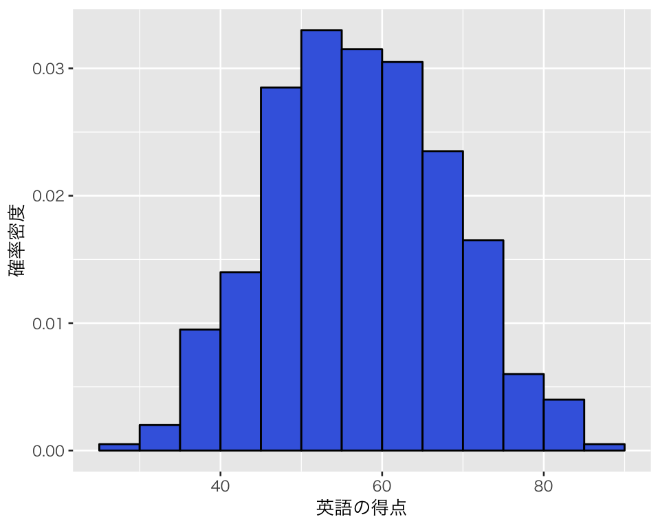

```r
hist_eng <- ggplot(myd, aes(x = english, y = ..density..)) +
  geom_histogram(binwidth = 5, boundary = 60, color = "black", fill = "royalblue") +
  labs(x = "英語の得点", y = "確率密度")
plot(hist_eng)
```

# 2. 化学の得点をクラスごとに比較する

化学の得点は、chemistry という変数に記録されている。また、クラスは class という変数に記録されている。 バイオリン図の上に箱ひげ図を、さらにその上に蜂群図を描こう。

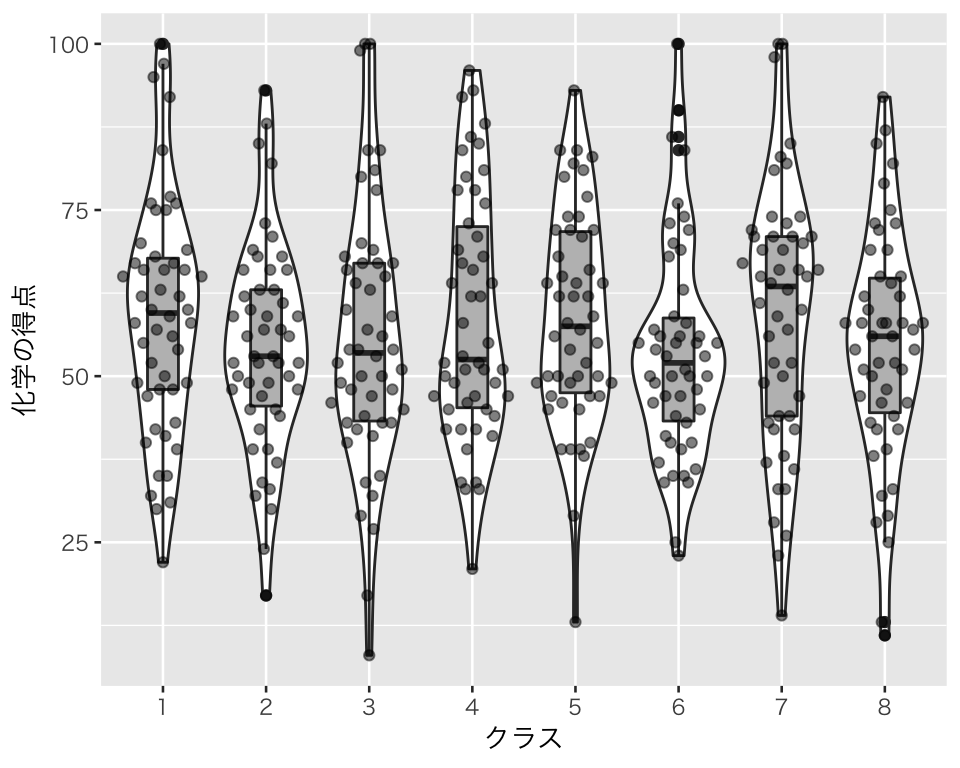

```r
chem_class <- ggplot(myd, aes(x = as.factor(class), y = chemistry)) +
  geom_violin() +
  geom_boxplot(width = 0.3, fill = "gray") +
  geom_quasirandom(alpha = 1/2) +
  labs(x = "クラス", y = "化学の得点")
plot(chem_class)
```

この図から、化学の得点のクラスごとの分布がわかる。例えば、クラス6の得点のばらつきは他のクラスより小さく、50点付近に固まっていることがわかる。しかし、高得点の外れ値も存在する。クラス3, 4, 5, 7 のばらつきは、相対的に大きい。中央値が最も高いのはクラス7である。全体的に化学の点数はばらつきが大きく、どのクラスにも25点以下をとった者もいれば、80点以上をとった者もいる。特に化学が得意なクラスや苦手なクラスが存在するかどうか、このデータからははっきりわからない。

# 3. 散布図

化学の得点 chemistry と数学の得点 math の散布図を描く。ただし、性別 gender によって点の色 (color_ と形 (shape) を分ける。

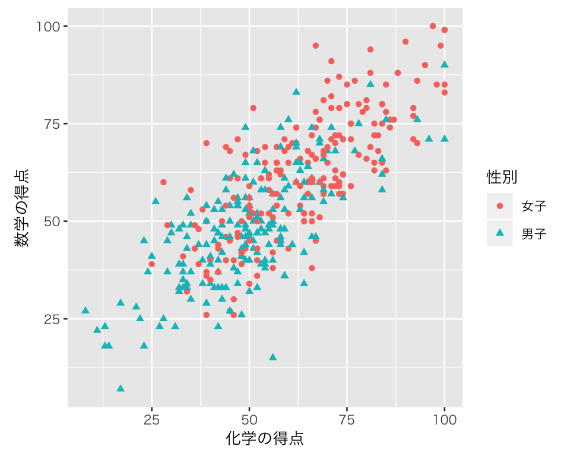

```r
scat <- ggplot(myd, aes(x = chemistry, y = math,
                        color = gender, shape = gender)) +
  geom_point() +
  labs(x = "化学の得点", y = "数学の得点") +
  scale_color_discrete(name = "性別", labels = c("女子", "男子")) +
  scale_shape_discrete(name = "性別", labels = c("女子", "男子")) +
  coord_fixed(ratio = 1)
plot(scat)
```

この散布図を見ると、全体的に点が右上がりの直線の周りに集まっているように見える。つまり、化学の点数が高いほど、数学の点数も高いという傾向がありそうだ。相関係数を確かめてみよう。

```r
with(myd, cor(chemistry, math))
```

```
## [1] 0.7779277
```

相関係数は約0.78 であり、正の相関がある。

また、男女別にみると、女子の点が右上に、男子の点が左下に集まっているので、数学と化学の両方で、女子の点数の方が男子の点数よりも高い傾向がある。

授業の内容に戻る